# 第一部分： Jupyter Notebook使用

## 1.1、Jupyter Notebook简介

### 初阶入门知识

什么是Jupyter Notebook？嗯，你现在正在浏览的就是一个Jupyter Notebook。它是有大量模块组成的一个文件。你可以在其中进行纯文本格式的编辑（Markdown模块），也可以进行R (python) 的编程（Code模块）并直接进行运行。如下所示：

```r
1+2
```

[output not shown]

> Jupyter Notebook是基于网页的用于交互计算的应用程序。其可被应用于全过程计算：开发、文档编写、运行代码和展示结果。—— [Jupyter Notebook 官方介绍](https://jupyter-notebook.readthedocs.io/en/stable/notebook.html)

这种代码和文本编辑的混合模式，使Jupyter Notebook可以非常直观的看到代码、代码的注释以及运行代码后的运算结果。

### 特点

1、 编程时具有语法高亮、缩进、tab补全的功能。

2、 可直接通过浏览器运行代码，同时在代码块下方展示运行结果。

3、 以富媒体格式展示计算结果。富媒体格式包括：HTML，LaTeX，PNG，SVG等。

4、 对代码编写说明文档或语句时，支持Markdown语法。

5、 支持使用LaTeX编写。

$$ \frac{1}{3}$$

# 主界面

[figure not shown]

### 文本编辑

Jupyter Notebook中用来进行文本编辑的模块叫做_Markdown_模块. [*Markdown*](https://en.wikipedia.org/wiki/Markdown)是一种非常流行的标记语言。定义一个模块是_Markdown_模块，你需要按工具栏中的下拉菜单，并选择_Markdown_选项。

现在按一下菜单栏左边的'+'按钮，然后选择菜单栏右边的_Markdown_选项。

[figure not shown]

现在你可以在你的_Markdown_模块中写下'My first markdown cell'，然后按'运行'。

你将会看到如下的运行结果：

My first markdown cell

```r
3/2
```

[output not shown]

### 模式

如果你在*Markdown*模块中输入了内容并运行后，你会发现如果你只单击它，你并不能修改此模块中的内容。这是因为你正处于**命令模式**下。Juypter Notebook有两种不同的模式：

1. **编辑模式**：让你对模块中的内容进行编辑。
2. **命令模式**: 让你对Jupyter Notebook整体内容，使用键盘快捷键进行编辑，但是此模式不能编辑一个模块中的具体内容。

你可以通过按`ESC`键和`Enter`键，或者单击模块外或模块内（对_Markdown_模块需要双击），在两种不同的模式间进行切换。此外，通过留意模块外的边框颜色，你也可以知道目前正处于的模式状态（绿色边框表示正处于**编辑模式**）。

### 其他注意事项

1. Jupyter Notebook默认每两分钟自动保存一次。你也可以通过按菜单栏的保存按钮，或者在**命令模式**下按`s`键，保存文件。

[figure not shown]

1. 如果你想知道计算机是否正在进行运算，你可以留意Notebook右上角的圆圈。如果圆圈处于实心状态，这表明机器正在进行运算；如果是空心的圆圈，表明机器正处于闲置状态。

[figure not shown]

1. 一些在**命令模式**下的常用键盘快捷键：

`Shift`+`Enter`: 运行_Markdown_或_Code_模块；

`Up Arrow`+`Down Arrow`: 在模块间上下移动；

`a`: 在上方创建新模块；

`b`: 在下方创建新模块;

`y`: 把标记（markdown）块转换成代码（code）;

`m`: 把代码（code）块转换成标记（markdown）;

`d`+`d`: 删除模块；

# 1.2、Jupyter Notebooks使用进阶

### _Markdown_模块扩展编辑

#### 斜体，粗体，内联，引用块及超链接格式：

1. *斜体*: 文本两侧用 '_' 或 '*' 标注；
2. **粗体**: 文本两侧用 '__' 或 '**' 标注；
3. `内联`: 文本两侧用 '`' 标注；
4. > blockquote: 文本前用 '>' 标注；
5. [超链接](https://liulab.fudan.edu.cn/teaching.html): 链接文本两侧用 '[]' 标注，并将链接的地址放在文本后的括弧内 '()' 。

#### 标题

_Markdown_模块前的井号代表此模块中的文字是标题。最前面井号的数目代表此标题的层级（'#'代表第一级标题，'##'代表第二级标题，'###'代表第三级标题，'####'代表第四级标题）。

#### 列表

*Markdown*模块中有三种不同的列表：

有序列表：

1. 第一步
2. 第二步
3. 第三步

无序列表：文字前加 ' * ' 或 ' - ' 或‘ + ’和一个空格

- learning rate
- cycle length
- weight decay

任务列表

- [x] Learn Jupyter Notebooks
  - [x] Writing
  - [x] Modes
  - [x] Other Considerations
- [ ] Change the world

请双击这些单元，并观察其标注格式。

### _Code_模块操作

**Code**模块和**Markdown**模块最大的区别在于，它后面有一个输出模块。这使我们可以在共享文档的同时，共享文档代码运行后的*最终结果*。这些结果在我们下一次打开文档的时候，还能展示在那里。

```r
x = 1:4
```

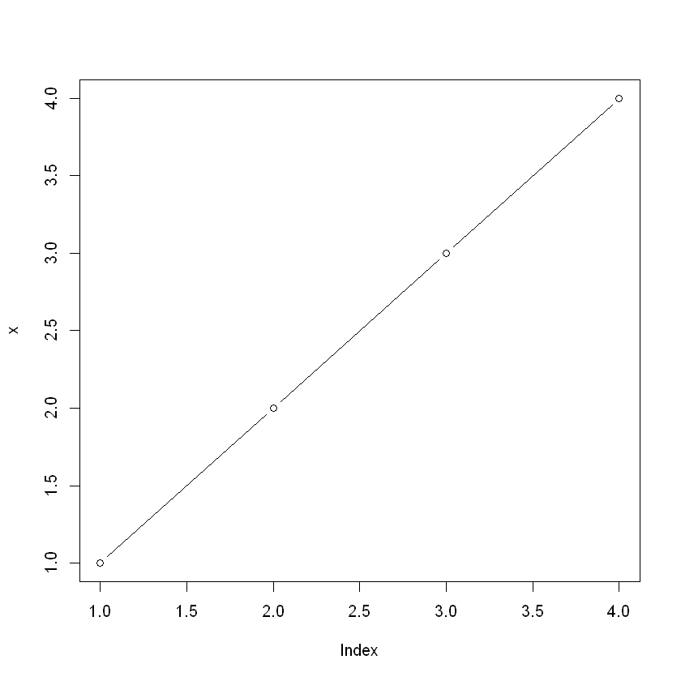

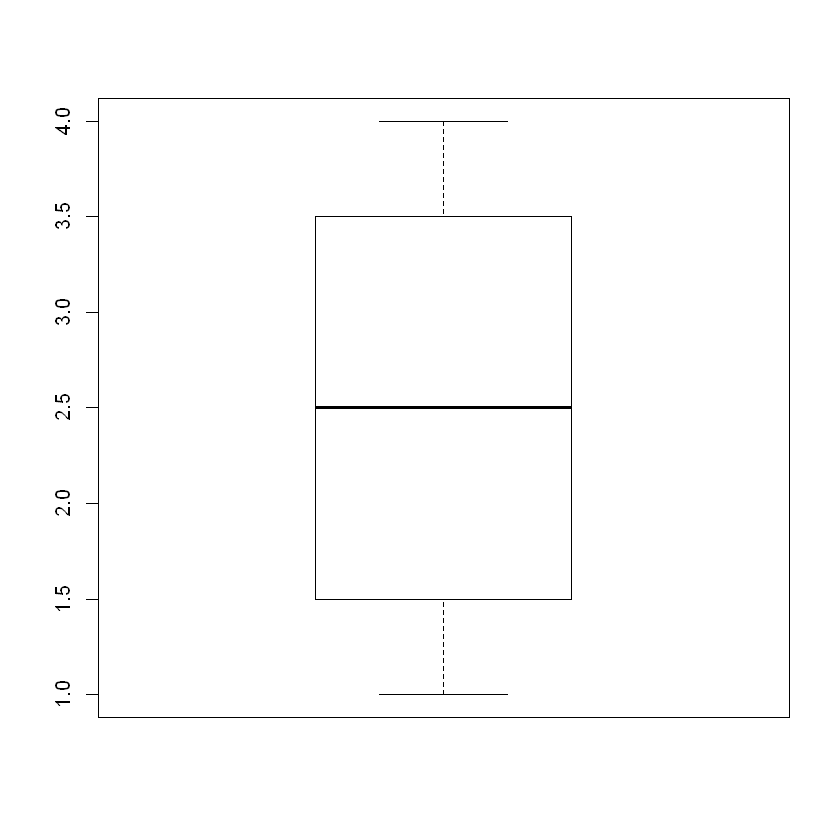

```r
plot(x,type = "b")
boxplot(x)
```